# Predict Bike Sharing Demand with AutoGluon Template

## Project: Predict Bike Sharing Demand with AutoGluon

This notebook is a template with each step that you need to complete for the project.

Please fill in your code where there are explicit `?` markers in the notebook. You are welcome to add more cells and code as you see fit.

Once you have completed all the code implementations, please export your notebook as a HTML file so the reviews can view your code. Make sure you have all outputs correctly outputted.

`File-> Export Notebook As... -> Export Notebook as HTML`

There is a writeup to complete as well after all code implememtation is done. Please answer all questions and attach the necessary tables and charts. You can complete the writeup in either markdown or PDF.

Completing the code template and writeup template will cover all of the rubric points for this project.

The rubric contains "Stand Out Suggestions" for enhancing the project beyond the minimum requirements. The stand out suggestions are optional. If you decide to pursue the "stand out suggestions", you can include the code in this notebook and also discuss the results in the writeup file.

## Step 1: Create an account with Kaggle

### Create Kaggle Account and download API key

Below is example of steps to get the API username and key. Each student will have their own username and key.

1. Open account settings.

2. Scroll down to API and click Create New API Token.

3. Open up `kaggle.json` and use the username and key.


## Step 2: Download the Kaggle dataset using the kaggle python library

### Open up Sagemaker Studio and use starter template

1. Notebook should be using a `ml.t3.medium` instance (2 vCPU + 4 GiB)
2. Notebook should be using kernal: `Python 3 (MXNet 1.8 Python 3.7 CPU Optimized)`

### Install packages

```python
!pip install -U pip
!pip install -U setuptools wheel
!pip install -U "mxnet<2.0.0" bokeh==2.0.1
!pip install autogluon --no-cache-dir
# Without --no-cache-dir, smaller aws instances may have trouble installing
```

### Setup Kaggle API Key

```python
!pwd
```

```
/home/sagemaker-user/cd0385-project-starter/project
```

```python
# create the .kaggle directory and an empty kaggle.json file
!mkdir -p /home/sagemaker-user/.kaggle
!touch /home/sagemaker-user/.kaggle/kaggle.json
!chmod 600 /home/sagemaker-user/.kaggle/kaggle.json
```

```python
# Fill in your user name and key from creating the kaggle account and API token file
import json
kaggle_username = ""
kaggle_key = ""

# Save API token the kaggle.json file
with open("/home/sagemaker-user/.kaggle/kaggle.json", "w") as f:
    f.write(json.dumps({"username": kaggle_username, "key": kaggle_key}))
```

### Download and explore dataset

### Go to the bike sharing demand competition and agree to the terms

```python
!pip install kaggle
```

```
  Using cached kaggle-1.6.12-py3-none-any.whl
```

```python
# Download the dataset, it will be in a .zip file so you'll need to unzip it as well.
!kaggle competitions download -c bike-sharing-demand
# If you already downloaded it you can use the -o command to overwrite the file
!unzip -o bike-sharing-demand.zip
```

```
Downloading bike-sharing-demand.zip to /home/sagemaker-user/cd0385-project-starter/project
Archive:  bike-sharing-demand.zip
  inflating: sampleSubmission.csv
  inflating: test.csv
  inflating: train.csv
```

```python
import pandas as pd
from autogluon.tabular import TabularPredictor
```

```python
# Create the train dataset in pandas by reading the csv
# Set the parsing of the datetime column so you can use some of the `dt` features in pandas later
train = pd.read_csv("train.csv", parse_dates=["datetime"])
train.head()
```

|  | datetime | season | holiday | workingday | weather | temp | atemp | humidity | windspeed | casual | registered | count |
| --- | --- | --- | --- | --- | --- | --- | --- | --- | --- | --- | --- | --- |
| 0 | 2011-01-01 00:00:00 | 1 | 0 | 0 | 1 | 9.84 | 14.395 | 81 | 0.0 | 3 | 13 | 16 |
| 1 | 2011-01-01 01:00:00 | 1 | 0 | 0 | 1 | 9.02 | 13.635 | 80 | 0.0 | 8 | 32 | 40 |
| 2 | 2011-01-01 02:00:00 | 1 | 0 | 0 | 1 | 9.02 | 13.635 | 80 | 0.0 | 5 | 27 | 32 |
| 3 | 2011-01-01 03:00:00 | 1 | 0 | 0 | 1 | 9.84 | 14.395 | 75 | 0.0 | 3 | 10 | 13 |
| 4 | 2011-01-01 04:00:00 | 1 | 0 | 0 | 1 | 9.84 | 14.395 | 75 | 0.0 | 0 | 1 | 1 |

```python
# Simple output of the train dataset to view some of the min/max/varition of the dataset features.
train.describe()
```

|  | season | holiday | workingday | weather | temp | atemp | humidity | windspeed | casual | registered | count |
| --- | --- | --- | --- | --- | --- | --- | --- | --- | --- | --- | --- |
| count | 10886.000000 | 10886.000000 | 10886.000000 | 10886.000000 | 10886.00000 | 10886.000000 | 10886.000000 | 10886.000000 | 10886.000000 | 10886.000000 | 10886.000000 |
| mean | 2.506614 | 0.028569 | 0.680875 | 1.418427 | 20.23086 | 23.655084 | 61.886460 | 12.799395 | 36.021955 | 155.552177 | 191.574132 |
| std | 1.116174 | 0.166599 | 0.466159 | 0.633839 | 7.79159 | 8.474601 | 19.245033 | 8.164537 | 49.960477 | 151.039033 | 181.144454 |
| min | 1.000000 | 0.000000 | 0.000000 | 1.000000 | 0.82000 | 0.760000 | 0.000000 | 0.000000 | 0.000000 | 0.000000 | 1.000000 |
| 25% | 2.000000 | 0.000000 | 0.000000 | 1.000000 | 13.94000 | 16.665000 | 47.000000 | 7.001500 | 4.000000 | 36.000000 | 42.000000 |
| 50% | 3.000000 | 0.000000 | 1.000000 | 1.000000 | 20.50000 | 24.240000 | 62.000000 | 12.998000 | 17.000000 | 118.000000 | 145.000000 |
| 75% | 4.000000 | 0.000000 | 1.000000 | 2.000000 | 26.24000 | 31.060000 | 77.000000 | 16.997900 | 49.000000 | 222.000000 | 284.000000 |
| max | 4.000000 | 1.000000 | 1.000000 | 4.000000 | 41.00000 | 45.455000 | 100.000000 | 56.996900 | 367.000000 | 886.000000 | 977.000000 |

```python
# Create the test pandas dataframe in pandas by reading the csv, remember to parse the datetime!
test = pd.read_csv("test.csv",parse_dates=["datetime"])
test.head()
```

|  | datetime | season | holiday | workingday | weather | temp | atemp | humidity | windspeed |
| --- | --- | --- | --- | --- | --- | --- | --- | --- | --- |
| 0 | 2011-01-20 00:00:00 | 1 | 0 | 1 | 1 | 10.66 | 11.365 | 56 | 26.0027 |
| 1 | 2011-01-20 01:00:00 | 1 | 0 | 1 | 1 | 10.66 | 13.635 | 56 | 0.0000 |
| 2 | 2011-01-20 02:00:00 | 1 | 0 | 1 | 1 | 10.66 | 13.635 | 56 | 0.0000 |
| 3 | 2011-01-20 03:00:00 | 1 | 0 | 1 | 1 | 10.66 | 12.880 | 56 | 11.0014 |
| 4 | 2011-01-20 04:00:00 | 1 | 0 | 1 | 1 | 10.66 | 12.880 | 56 | 11.0014 |

```python
# Same thing as train and test dataset
submission = pd.read_csv("sampleSubmission.csv",parse_dates=["datetime"])
submission.head()
```

|  | datetime | count |
| --- | --- | --- |
| 0 | 2011-01-20 00:00:00 | 0 |
| 1 | 2011-01-20 01:00:00 | 0 |
| 2 | 2011-01-20 02:00:00 | 0 |
| 3 | 2011-01-20 03:00:00 | 0 |
| 4 | 2011-01-20 04:00:00 | 0 |

## Step 3: Train a model using AutoGluon’s Tabular Prediction

Requirements:

- We are prediting `count`, so it is the label we are setting.
- Ignore `casual` and `registered` columns as they are also not present in the test dataset.
- Use the `root_mean_squared_error` as the metric to use for evaluation.
- Set a time limit of 10 minutes (600 seconds).
- Use the preset `best_quality` to focus on creating the best model.

```python
predictor=TabularPredictor(label="count", eval_metric="root_mean_squared_error",learner_kwargs={"ignored_columns": ["casual", "registered"]}).fit(train_data=train,
                                                  time_limit=600,presets="best_quality")
```

```
No path specified. Models will be saved in: "AutogluonModels/ag-20240430_212425"
Presets specified: ['best_quality']
Stack configuration (auto_stack=True): num_stack_levels=1, num_bag_folds=8, num_bag_sets=20
Beginning AutoGluon training ... Time limit = 600s
AutoGluon will save models to "AutogluonModels/ag-20240430_212425"
AutoGluon Version:  0.8.2
Python Version:     3.10.14
Operating System:   Linux
Platform Machine:   x86_64
Platform Version:   #1 SMP Sat Mar 23 09:49:55 UTC 2024
Disk Space Avail:   4.71 GB / 16.10 GB (29.3%)
	WARNING: Available disk space is low and there is a risk that AutoGluon will run out of disk during fit, causing an exception.
	We recommend a minimum available disk space of 10 GB, and large datasets may require more.
Train Data Rows:    10886
Train Data Columns: 11
Label Column: count
Preprocessing data ...
AutoGluon infers your prediction problem is: 'regression' (because dtype of label-column == int and many unique label-values observed).
	Label info (max, min, mean, stddev): (977, 1, 191.57413, 181.14445)
	If 'regression' is not the correct problem_type, please manually specify the problem_type parameter during predictor init (You may specify problem_type as one of: ['binary', 'multiclass', 'regression'])
Using Feature Generators to preprocess the data ...
Dropping user-specified ignored columns: ['casual', 'registered']
Fitting AutoMLPipelineFeatureGenerator...
	Available Memory:                    2204.92 MB
	Train Data (Original)  Memory Usage: 0.78 MB (0.0% of available memory)
	Inferring data type of each feature based on column values. Set feature_metadata_in to manually specify special dtypes of the features.
	Stage 1 Generators:
		Fitting AsTypeFeatureGenerator...
			Note: Converting 2 features to boolean dtype as they only contain 2 unique values.
	Stage 2 Generators:
		Fitting FillNaFeatureGenerator...
	Stage 3 Generators:
		Fitting IdentityFeatureGenerator...
		Fitting DatetimeFeatureGenerator...
	Stage 4 Generators:
		Fitting DropUniqueFeatureGenerator...
	Stage 5 Generators:
		Fitting DropDuplicatesFeatureGenerator...
	Types of features in original data (raw dtype, special dtypes):
		('datetime', []) : 1 | ['datetime']
```

[output cut: 13 more lines]

```
	To change this, specify the eval_metric parameter of Predictor()
User-specified model hyperparameters to be fit:
{
	'NN_TORCH': {},
	'GBM': [{'extra_trees': True, 'ag_args': {'name_suffix': 'XT'}}, {}, 'GBMLarge'],
	'CAT': {},
	'XGB': {},
	'FASTAI': {},
	'RF': [{'criterion': 'gini', 'ag_args': {'name_suffix': 'Gini', 'problem_types': ['binary', 'multiclass']}}, {'criterion': 'entropy', 'ag_args': {'name_suffix': 'Entr', 'problem_types': ['binary', 'multiclass']}}, {'criterion': 'squared_error', 'ag_args': {'name_suffix': 'MSE', 'problem_types': ['r…
	'XT': [{'criterion': 'gini', 'ag_args': {'name_suffix': 'Gini', 'problem_types': ['binary', 'multiclass']}}, {'criterion': 'entropy', 'ag_args': {'name_suffix': 'Entr', 'problem_types': ['binary', 'multiclass']}}, {'criterion': 'squared_error', 'ag_args': {'name_suffix': 'MSE', 'problem_types': ['r…
	'KNN': [{'weights': 'uniform', 'ag_args': {'name_suffix': 'Unif'}}, {'weights': 'distance', 'ag_args': {'name_suffix': 'Dist'}}],
}
AutoGluon will fit 2 stack levels (L1 to L2) ...
Fitting 11 L1 models ...
Fitting model: KNeighborsUnif_BAG_L1 ... Training model for up to 399.77s of the 599.8s of remaining time.
```

[output not shown]

[output cut: 369 more lines]

### Review AutoGluon's training run with ranking of models that did the best.

```python
predictor.fit_summary()
```

```
*** Summary of fit() ***
Estimated performance of each model:
                     model   score_val  pred_time_val    fit_time  pred_time_val_marginal  fit_time_marginal  stack_level  can_infer  fit_order
0      WeightedEnsemble_L3  -52.718763      12.226391  524.107032                0.000948           0.317621            3       True         16
1   RandomForestMSE_BAG_L2  -53.298921      11.120296  420.148500                0.610877          45.222874            2       True         13
2     ExtraTreesMSE_BAG_L2  -53.726166      11.340939  388.784946                0.831520          13.859320            2       True         15
3          LightGBM_BAG_L2  -55.047770      10.728978  387.285753                0.219559          12.360127            2       True         12
4          CatBoost_BAG_L2  -55.457992      10.563486  452.347090                0.054067          77.421464            2       True         14
5        LightGBMXT_BAG_L2  -60.057500      13.992164  419.334983                3.482745          44.409357            2       True         11
6    KNeighborsDist_BAG_L1  -84.125061       0.078021    0.038836                0.078021           0.038836            1       True          2
7      WeightedEnsemble_L2  -84.125061       0.078757    0.601821                0.000737           0.562984            2       True         10
8    KNeighborsUnif_BAG_L1 -101.546199       0.058837    0.040252                0.058837           0.040252            1       True          1
9   RandomForestMSE_BAG_L1 -116.548359       0.727794   15.936839                0.727794          15.936839            1       True          5
10    ExtraTreesMSE_BAG_L1 -124.600676       0.731745    7.525803                0.731745           7.525803            1       True          7
11         CatBoost_BAG_L1 -130.503441       0.076469  231.759237                0.076469         231.759237            1       True          6
12         LightGBM_BAG_L1 -131.054162       1.246548   12.936166                1.246548          12.936166            1       True          4
13       LightGBMXT_BAG_L1 -131.460909       7.181166   51.792514                7.181166          51.792514            1       True          3
14          XGBoost_BAG_L1 -132.141517       0.190741    4.488152                0.190741           4.488152            1       True          9
15  NeuralNetFastAI_BAG_L1 -138.669361       0.218097   50.407826                0.218097          50.407826            1       True          8
Number of models trained: 16
Types of models trained:
{'StackerEnsembleModel_RF', 'StackerEnsembleModel_XGBoost', 'StackerEnsembleModel_KNN', 'StackerEnsembleModel_LGB', 'WeightedEnsembleModel', 'StackerEnsembleModel_CatBoost', 'StackerEnsembleModel_XT', 'StackerEnsembleModel_NNFastAiTabular'}
Bagging used: True  (with 8 folds)
Multi-layer stack-ensembling used: True  (with 3 levels)
Feature Metadata (Processed):
(raw dtype, special dtypes):
('float', [])                : 3 | ['temp', 'atemp', 'windspeed']
('int', [])                  : 3 | ['season', 'weather', 'humidity']
('int', ['bool'])            : 2 | ['holiday', 'workingday']
('int', ['datetime_as_int']) : 5 | ['datetime', 'datetime.year', 'datetime.month', 'datetime.day', 'datetime.dayofweek']
*** End of fit() summary ***
```

[output not shown]

[output cut: 151 more lines]

```
 1          13
 2          15
 3          12
 4          14
 5          11
 6           2
 7          10
 8           1
 9           5
 10          7
 11          6
 12          4
 13          3
 14          9
 15          8  }
```

### Create predictions from test dataset

```python
predictions = predictor.predict(test)
predictions.head()
```

```
0    22.367300
1    42.268768
2    46.192787
3    48.407219
4    51.926178
Name: count, dtype: float32
```

#### NOTE: Kaggle will reject the submission if we don't set everything to be > 0.

```python
# Describe the `predictions` series to see if there are any negative values
predictions.describe()
```

```
count    6493.000000
mean      101.034935
std        90.353081
min         2.975072
25%        20.717861
50%        62.920708
75%       171.175018
max       363.104034
Name: count, dtype: float64
```

```python
# How many negative values do we have?
#There is 0 Negative Values
```

```python
# Set them to zero
#There is no Negative Values
```

### Set predictions to submission dataframe, save, and submit

```python
submission["count"] = predictions
submission.to_csv("submission.csv", index=False)
```

```python
!kaggle competitions submit -c bike-sharing-demand -f submission.csv -m "first raw submission"
```

```
Successfully submitted to Bike Sharing Demand
```

#### View submission via the command line or in the web browser under the competition's page - `My Submissions`

```python
!kaggle competitions submissions -c bike-sharing-demand | tail -n +1 | head -n 6
```

```
fileName                     date                 description                        status    publicScore  privateScore
---------------------------  -------------------  ---------------------------------  --------  -----------  ------------
submission.csv               2024-04-30 11:48:21  first raw submission               complete  1.80341      1.80341
submission_new_features.csv  2024-04-30 11:48:01  new features                       complete  0.71576      0.71576
submission_new_hpo.csv       2024-04-29 21:11:54  new features with hyperparameters  complete  0.65785      0.65785
submission_new_features.csv  2024-04-29 21:05:24  new features                       complete  0.65785      0.65785
```

#### Initial score of `1.80341`

## Step 4: Exploratory Data Analysis and Creating an additional feature

- Any additional feature will do, but a great suggestion would be to separate out the datetime into hour, day, or month parts.

```python
train.sample()
```

|  | datetime | season | holiday | workingday | weather | temp | atemp | humidity | windspeed | casual | registered | count |
| --- | --- | --- | --- | --- | --- | --- | --- | --- | --- | --- | --- | --- |
| 4024 | 2011-09-18 17:00:00 | 3 | 0 | 0 | 2 | 22.96 | 26.515 | 64 | 12.998 | 95 | 230 | 325 |

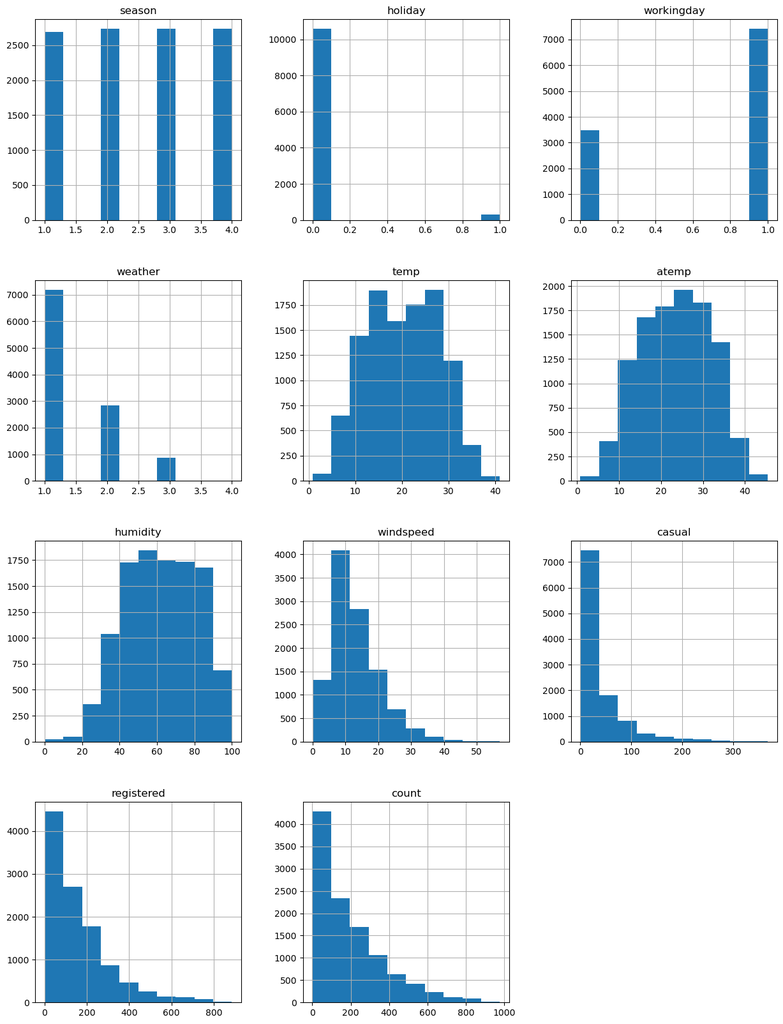

```python
# Create a histogram of all features to show the distribution of each one relative to the data. This is part of the exploritory data analysis
import matplotlib.pyplot as plt
%matplotlib inline
train.hist(figsize=(15, 20))
plt.show();
```

```python
# create a new feature
train['datetime'] = pd.to_datetime(train['datetime'])
train["year"] = train['datetime'].dt.year
train["month"] = train['datetime'].dt.month
train["dayofweek"] = train['datetime'].dt.dayofweek
train["hour"] = train['datetime'].dt.hour

test['datetime'] = pd.to_datetime(test['datetime'])
test["month"] = test['datetime'].dt.month
test["year"] = test['datetime'].dt.year
test["dayofweek"] = test['datetime'].dt.dayofweek
test["hour"] = test['datetime'].dt.hour
```

```python
!pip install seaborn
```

```
Downloading seaborn-0.13.2-py3-none-any.whl (294 kB)
   ━━━━━━━━━━━━━━━━━━━━━━━━━━━━━━━━━━━━━━━━ 294.9/294.9 kB 20.9 MB/s eta 0:00:00
```

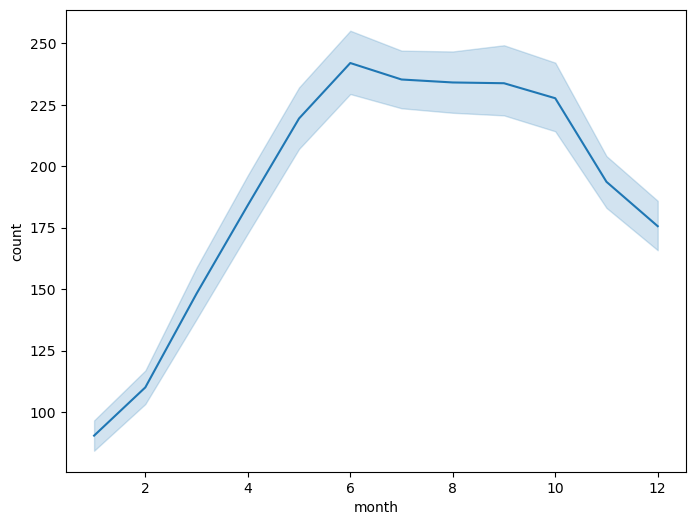

```python
import seaborn as sns
import matplotlib.pyplot as plt

# Assuming your DataFrame is called 'train' and the two features are named 'feature1' and 'feature2'
plt.figure(figsize=(8, 6))

# Plot line for first feature
sns.lineplot(train,x=train['month'], y = train["count"])
```

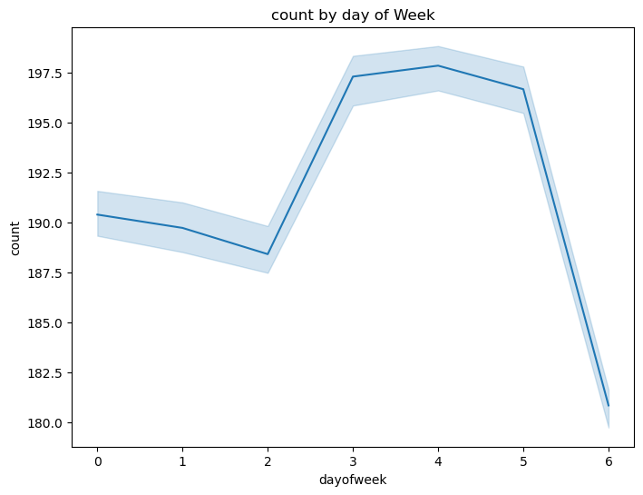

```python
plt.figure(figsize=(8, 6))
plt.title("count by day of Week")
# Plot line for first feature
sns.lineplot(train,x=train['dayofweek'], y = train["count"], errorbar=('ci', 20));
```

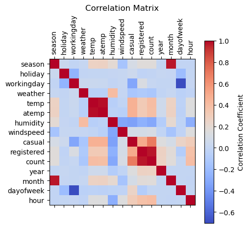

```python
correlation_matrix = train.corr()

plt.matshow(correlation_matrix, cmap='coolwarm')

plt.xticks(range(len(correlation_matrix.columns)), correlation_matrix.columns, rotation=90)
plt.yticks(range(len(correlation_matrix.columns)), correlation_matrix.columns)
plt.colorbar(label='Correlation Coefficient')
plt.title('Correlation Matrix')
plt.grid(False)
plt.tight_layout()

plt.show()
```

## Make category types for these so models know they are not just numbers

- AutoGluon originally sees these as ints, but in reality they are int representations of a category.
- Setting the dtype to category will classify these as categories in AutoGluon.

```python
train["season"] = train["season"].astype("category")
train["weather"] = train["weather"].astype("category")
test["season"] = test["season"].astype("category")
test["weather"] = test["weather"].astype("category")
```

```python
train = train.drop("datetime", axis = 1)
test = test.drop("datetime", axis = 1)
```

```python
train.info()
```

```
<class 'pandas.core.frame.DataFrame'>
RangeIndex: 10886 entries, 0 to 10885
Data columns (total 15 columns):
 #   Column      Non-Null Count  Dtype
---  ------      --------------  -----
 0   season      10886 non-null  category
 1   holiday     10886 non-null  int64
 2   workingday  10886 non-null  int64
 3   weather     10886 non-null  category
 4   temp        10886 non-null  float64
 5   atemp       10886 non-null  float64
 6   humidity    10886 non-null  int64
 7   windspeed   10886 non-null  float64
 8   casual      10886 non-null  int64
 9   registered  10886 non-null  int64
 10  count       10886 non-null  int64
 11  year        10886 non-null  int32
 12  month       10886 non-null  int32
 13  dayofweek   10886 non-null  int32
 14  hour        10886 non-null  int32
dtypes: category(2), float64(3), int32(4), int64(6)
memory usage: 957.3 KB
```

```python
test.info()
```

```
<class 'pandas.core.frame.DataFrame'>
RangeIndex: 6493 entries, 0 to 6492
Data columns (total 12 columns):
 #   Column      Non-Null Count  Dtype
---  ------      --------------  -----
 0   season      6493 non-null   category
 1   holiday     6493 non-null   int64
 2   workingday  6493 non-null   int64
 3   weather     6493 non-null   category
 4   temp        6493 non-null   float64
 5   atemp       6493 non-null   float64
 6   humidity    6493 non-null   int64
 7   windspeed   6493 non-null   float64
 8   month       6493 non-null   int32
 9   year        6493 non-null   int32
 10  dayofweek   6493 non-null   int32
 11  hour        6493 non-null   int32
dtypes: category(2), float64(3), int32(4), int64(3)
memory usage: 419.0 KB
```

```python
# View are new feature
train.head()
```

|  | season | holiday | workingday | weather | temp | atemp | humidity | windspeed | casual | registered | count | year | month | dayofweek | hour |
| --- | --- | --- | --- | --- | --- | --- | --- | --- | --- | --- | --- | --- | --- | --- | --- |
| 0 | 1 | 0 | 0 | 1 | 9.84 | 14.395 | 81 | 0.0 | 3 | 13 | 16 | 2011 | 1 | 5 | 0 |
| 1 | 1 | 0 | 0 | 1 | 9.02 | 13.635 | 80 | 0.0 | 8 | 32 | 40 | 2011 | 1 | 5 | 1 |
| 2 | 1 | 0 | 0 | 1 | 9.02 | 13.635 | 80 | 0.0 | 5 | 27 | 32 | 2011 | 1 | 5 | 2 |
| 3 | 1 | 0 | 0 | 1 | 9.84 | 14.395 | 75 | 0.0 | 3 | 10 | 13 | 2011 | 1 | 5 | 3 |
| 4 | 1 | 0 | 0 | 1 | 9.84 | 14.395 | 75 | 0.0 | 0 | 1 | 1 | 2011 | 1 | 5 | 4 |

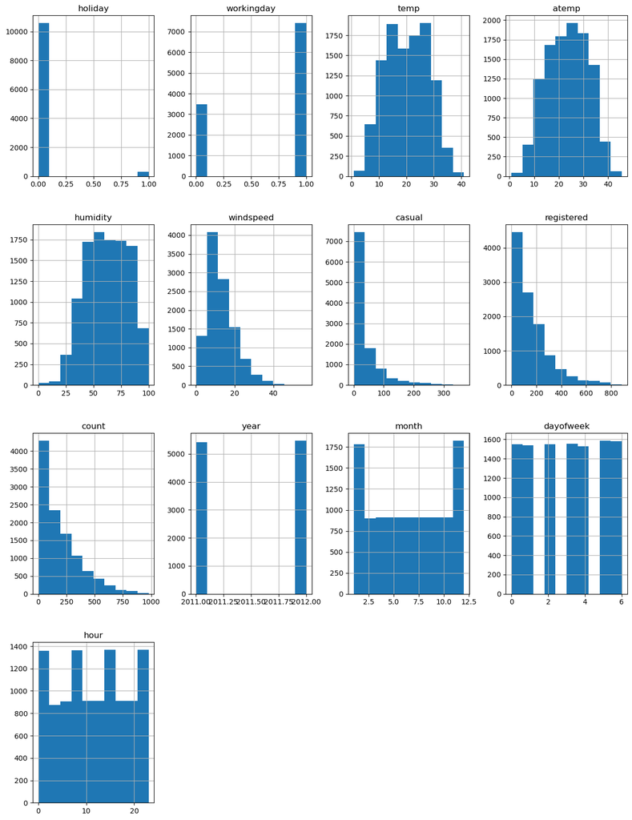

```python
# View histogram of all features again now with the hour feature
train.hist(figsize=(15, 20))
plt.show();
```

## Step 5: Rerun the model with the same settings as before, just with more features

```python
predictor_new_features = TabularPredictor(label="count", problem_type="regression", eval_metric="root_mean_squared_error",learner_kwargs={"ignored_columns": ["casual", "registered"]}).fit(train_data=train,
                                                  time_limit=600,presets="best_quality")
```

[output not shown]

[output cut: 26 more lines]

[output not shown]

[output not shown]

[output cut: 324 more lines]

```python
predictor_new_features.fit_summary()
```

```
*** Summary of fit() ***
Estimated performance of each model:
                     model   score_val  pred_time_val    fit_time  pred_time_val_marginal  fit_time_marginal  stack_level  can_infer  fit_order
0      WeightedEnsemble_L3  -33.836366      17.145397  498.429890                0.000699           0.389651            3       True         17
1     ExtraTreesMSE_BAG_L2  -34.112646      16.691079  380.227624                0.746842          11.225491            2       True         14
2      WeightedEnsemble_L2  -34.141706      15.556289  368.054238                0.000664           0.456453            2       True          9
3          CatBoost_BAG_L2  -34.322803      15.995136  430.382173                0.050900          61.380040            2       True         13
4   NeuralNetFastAI_BAG_L2  -34.427763      16.228326  421.839911                0.284089          52.837778            2       True         15
5          LightGBM_BAG_L2  -34.469859      16.056515  381.293130                0.112278          12.290997            2       True         11
6           XGBoost_BAG_L2  -34.664749      16.062868  372.596931                0.118631           3.594798            2       True         16
7   RandomForestMSE_BAG_L2  -34.851499      16.583470  408.897017                0.639233          39.894884            2       True         12
8        LightGBMXT_BAG_L2  -35.085928      16.242805  383.037938                0.298568          14.035805            2       True         10
9          CatBoost_BAG_L1  -35.737019       0.133062  255.636371                0.133062         255.636371            1       True          6
10         LightGBM_BAG_L1  -35.796869       2.515747   24.502003                2.515747          24.502003            1       True          4
11       LightGBMXT_BAG_L1  -36.459884      11.566796   66.917367               11.566796          66.917367            1       True          3
12    ExtraTreesMSE_BAG_L1  -39.033394       0.717696    7.378480                0.717696           7.378480            1       True          7
13  RandomForestMSE_BAG_L1  -39.587441       0.622324   13.163564                0.622324          13.163564            1       True          5
14          XGBoost_BAG_L1  -47.444011       0.102796    1.345518                0.102796           1.345518            1       True          8
15   KNeighborsDist_BAG_L1 -112.157112       0.138798    0.027859                0.138798           0.027859            1       True          2
16   KNeighborsUnif_BAG_L1 -115.733231       0.147018    0.030972                0.147018           0.030972            1       True          1
Number of models trained: 17
Types of models trained:
{'StackerEnsembleModel_RF', 'StackerEnsembleModel_XGBoost', 'StackerEnsembleModel_KNN', 'StackerEnsembleModel_LGB', 'WeightedEnsembleModel', 'StackerEnsembleModel_CatBoost', 'StackerEnsembleModel_XT', 'StackerEnsembleModel_NNFastAiTabular'}
Bagging used: True  (with 8 folds)
Multi-layer stack-ensembling used: True  (with 3 levels)
Feature Metadata (Processed):
(raw dtype, special dtypes):
('category', [])  : 2 | ['season', 'weather']
('float', [])     : 3 | ['temp', 'atemp', 'windspeed']
('int', [])       : 4 | ['humidity', 'month', 'dayofweek', 'hour']
('int', ['bool']) : 3 | ['holiday', 'workingday', 'year']
*** End of fit() summary ***
```

[output not shown]

[output cut: 163 more lines]

```
 2           9
 3          13
 4          15
 5          11
 6          16
 7          12
 8          10
 9           6
 10          4
 11          3
 12          7
 13          5
 14          8
 15          2
 16          1  }
```

```python
# Remember to set all negative values to zero
predictions_new_features = predictor_new_features.predict(test)
```

```python
# No negative Values found
predictions_new_features[predictions_new_features < 0 ] = 0
```

```python
# Same submitting predictions
submission_new_features = pd.read_csv("sampleSubmission.csv")
submission_new_features["count"] = predictions_new_features
submission_new_features.to_csv("submission_new_features.csv", index=False)
```

```python
!kaggle competitions submit -c bike-sharing-demand -f submission_new_features.csv -m "new features"
```

```
Successfully submitted to Bike Sharing Demand
```

```python
!kaggle competitions submissions -c bike-sharing-demand | tail -n +1 | head -n 6
```

```
fileName                     date                 description                        status    publicScore  privateScore
---------------------------  -------------------  ---------------------------------  --------  -----------  ------------
submission_new_features.csv  2024-04-30 14:53:23  new features                       complete  0.45264      0.45264
submission_new_hpo.csv       2024-04-30 14:45:26  new features with hyperparameters  complete  0.43639      0.43639
submission_new_features.csv  2024-04-30 14:36:39  new features                       error
submission_new_hpo.csv       2024-04-30 12:13:17  new features with hyperparameters  complete  0.65599      0.65599
```

#### New Score of `0.45264`

## Step 6: Hyper parameter optimization

- There are many options for hyper parameter optimization.
- Options are to change the AutoGluon higher level parameters or the individual model hyperparameters.
- The hyperparameters of the models themselves that are in AutoGluon. Those need the `hyperparameter` and `hyperparameter_tune_kwargs` arguments.

```python
import autogluon.core as ag

hyperparameters = {
    'GBM': [{'extra_trees': True,
                'num_boost_round': ag.space.Int(lower=100, upper=500, default=100),
                'num_leaves': ag.space.Int(lower=25, upper=64, default=36),
                'ag_args': {'name_suffix': 'XT'}}, {}, 'GBMLarge'],
    'CAT': {'iterations': 10000},
    'RF': {'n_estimators': 300},
    'XT': {'n_estimators': 300},
    'NN_TORCH':{'num_epochs': 5,
              'learning_rate': ag.space.Real(1e-4, 1e-2, default=5e-4, log=True),
                    # learning rate used in training (real-valued hyperparameter searched on log-scale)
              'activation': ag.space.Categorical('relu', 'softrelu', 'tanh'),
                    # activation function used in NN (categorical hyperparameter, default = first entry)
              'dropout_prob': ag.space.Real(0.0, 0.5, default=0.1)}
}

hyperparameter_tune_kwargs = {
    'num_trials': 200,
    'scheduler': 'local',
    'searcher': 'auto'
}

predictor_new_hpo = TabularPredictor(label="count", eval_metric="root_mean_squared_error",learner_kwargs={"ignored_columns": ["casual", "registered"]},
                                     problem_type = "regression").fit(train_data=train,
                                                  time_limit=1000,presets="best_quality", hyperparameters=hyperparameters, hyperparameter_tune_kwargs=hyperparameter_tune_kwargs)
```

[output not shown]

[output cut: 8 more lines]

```
Data preprocessing and feature engineering runtime = 0.11s ...
AutoGluon will gauge predictive performance using evaluation metric: 'root_mean_squared_error'
	This metric's sign has been flipped to adhere to being higher_is_better. The metric score can be multiplied by -1 to get the metric value.
	To change this, specify the eval_metric parameter of Predictor()
User-specified model hyperparameters to be fit:
{
	'GBM': [{'extra_trees': True, 'num_boost_round': Int: lower=100, upper=500, 'num_leaves': Int: lower=25, upper=64, 'ag_args': {'name_suffix': 'XT'}}, {}, 'GBMLarge'],
	'CAT': {'iterations': 10000},
	'RF': {'n_estimators': 300},
	'XT': {'n_estimators': 300},
	'NN_TORCH': {'num_epochs': 5, 'learning_rate': Real: lower=0.0001, upper=0.01, 'activation': Categorical['relu', 'softrelu', 'tanh'], 'dropout_prob': Real: lower=0.0, upper=0.5},
}
AutoGluon will fit 2 stack levels (L1 to L2) ...
Fitting 7 L1 models ...
Hyperparameter tuning model: LightGBMXT_BAG_L1 ... Tuning model for up to 85.68s of the 999.88s of remaining time.
```

[output not shown]

```
	Fitting 8 child models (S1F1 - S1F8) | Fitting with SequentialLocalFoldFittingStrategy
```

[output not shown]

```
	Fitting 8 child models (S1F1 - S1F8) | Fitting with SequentialLocalFoldFittingStrategy
	Fitting 8 child models (S1F1 - S1F8) | Fitting with SequentialLocalFoldFittingStrategy
```

```
[1000]	valid_set's rmse: 130.557
[1000]	valid_set's rmse: 134.435
[1000]	valid_set's rmse: 130.633
[1000]	valid_set's rmse: 130.583
```

```
	Fitting 8 child models (S1F1 - S1F8) | Fitting with SequentialLocalFoldFittingStrategy
```

```
[1000]	valid_set's rmse: 130.041
```

```
	Ran out of time, early stopping on iteration 1407. Best iteration is:
	[1406]	valid_set's rmse: 129.38
	Fitting 8 child models (S1F1 - S1F8) | Fitting with SequentialLocalFoldFittingStrategy
```

```
[1000]	valid_set's rmse: 132.027
```

```
	Stopping HPO to satisfy time limit...
Fitted model: LightGBM_BAG_L1/T1 ...
	-131.0542	 = Validation score   (-root_mean_squared_error)
	20.61s	 = Training   runtime
	0.0s	 = Validation runtime
Fitted model: LightGBM_BAG_L1/T2 ...
	-130.2954	 = Validation score   (-root_mean_squared_error)
	14.47s	 = Training   runtime
	0.0s	 = Validation runtime
Fitted model: LightGBM_BAG_L1/T3 ...
	-131.2525	 = Validation score   (-root_mean_squared_error)
	21.1s	 = Training   runtime
	0.0s	 = Validation runtime
Fitted model: LightGBM_BAG_L1/T5 ...
	-131.6264	 = Validation score   (-root_mean_squared_error)
	15.48s	 = Training   runtime
	0.0s	 = Validation runtime
Hyperparameter tuning model: RandomForest_BAG_L1 ... Tuning model for up to 85.68s of the 845.98s of remaining time.
	No hyperparameter search space specified for RandomForest_BAG_L1. Skipping HPO. Will train one model based on the provided hyperparameters.
Fitted model: RandomForest_BAG_L1 ...
	-116.5484	 = Validation score   (-root_mean_squared_error)
	17.39s	 = Training   runtime
	0.0s	 = Validation runtime
Hyperparameter tuning model: CatBoost_BAG_L1 ... Tuning model for up to 85.68s of the 828.55s of remaining time.
```

[output not shown]

[output not shown]

[output cut: 5994 more lines]

```
	-146.4602	 = Validation score   (-root_mean_squared_error)
	15.98s	 = Training   runtime
	0.26s	 = Validation runtime
Fitting model: LightGBMXT_BAG_L1/T7 ... Training model for up to 334.61s of the 668.06s of remaining time.
	Fitting 8 child models (S2F1 - S2F8) | Fitting with SequentialLocalFoldFittingStrategy
	-133.8799	 = Validation score   (-root_mean_squared_error)
	14.49s	 = Training   runtime
	0.18s	 = Validation runtime
Fitting model: LightGBMXT_BAG_L1/T8 ... Training model for up to 328.46s of the 661.92s of remaining time.
	Fitting 8 child models (S2F1 - S2F8) | Fitting with SequentialLocalFoldFittingStrategy
	-134.4479	 = Validation score   (-root_mean_squared_error)
	23.29s	 = Training   runtime
	0.66s	 = Validation runtime
Fitting model: LightGBM_BAG_L1/T1 ... Training model for up to 316.81s of the 650.27s of remaining time.
	Fitting 8 child models (S2F1 - S2F8) | Fitting with SequentialLocalFoldFittingStrategy
```

```
[1000]	valid_set's rmse: 131.878
[1000]	valid_set's rmse: 127.007
[1000]	valid_set's rmse: 134.715
[1000]	valid_set's rmse: 131.009
[1000]	valid_set's rmse: 127.975
[1000]	valid_set's rmse: 132.588
```

```
	-129.7975	 = Validation score   (-root_mean_squared_error)
	37.17s	 = Training   runtime
	1.25s	 = Validation runtime
Fitting model: LightGBM_BAG_L1/T2 ... Training model for up to 297.32s of the 630.78s of remaining time.
	Fitting 8 child models (S2F1 - S2F8) | Fitting with SequentialLocalFoldFittingStrategy
	-128.5025	 = Validation score   (-root_mean_squared_error)
	27.28s	 = Training   runtime
	0.24s	 = Validation runtime
Fitting model: LightGBM_BAG_L1/T3 ... Training model for up to 283.09s of the 616.55s of remaining time.
	Fitting 8 child models (S2F1 - S2F8) | Fitting with SequentialLocalFoldFittingStrategy
```

```
[1000]	valid_set's rmse: 131.594
[1000]	valid_set's rmse: 125.507
[1000]	valid_set's rmse: 134.917
[1000]	valid_set's rmse: 131.865
[1000]	valid_set's rmse: 128.054
```

```
	-129.9979	 = Validation score   (-root_mean_squared_error)
	42.27s	 = Training   runtime
	1.88s	 = Validation runtime
Fitting model: LightGBM_BAG_L1/T5 ... Training model for up to 257.53s of the 590.99s of remaining time.
	Fitting 8 child models (S2F1 - S2F8) | Fitting with SequentialLocalFoldFittingStrategy
	-130.2281	 = Validation score   (-root_mean_squared_error)
	28.82s	 = Training   runtime
	0.66s	 = Validation runtime
Fitting model: CatBoost_BAG_L1/T1 ... Training model for up to 242.37s of the 575.83s of remaining time.
	Fitting 8 child models (S2F1 - S2F8) | Fitting with SequentialLocalFoldFittingStrategy
	Ran out of time, early stopping on iteration 4084.
	Ran out of time, early stopping on iteration 4182.
	Ran out of time, early stopping on iteration 4174.
	Ran out of time, early stopping on iteration 4763.
	Ran out of time, early stopping on iteration 4870.
	Ran out of time, early stopping on iteration 5441.
	-129.8547	 = Validation score   (-root_mean_squared_error)
	309.15s	 = Training   runtime
	0.1s	 = Validation runtime
Fitting model: LightGBMLarge_BAG_L1 ... Training model for up to 10.42s of the 343.88s of remaining time.
	Fitting 8 child models (S2F1 - S2F8) | Fitting with SequentialLocalFoldFittingStrategy
	Ran out of time, early stopping on iteration 244. Best iteration is:
	[244]	valid_set's rmse: 132.476
	Time limit exceeded... Skipping LightGBMLarge_BAG_L1.
Completed 2/20 k-fold bagging repeats ...
Fitting model: WeightedEnsemble_L2 ... Training model for up to 360.0s of the 342.35s of remaining time.
	-116.5484	 = Validation score   (-root_mean_squared_error)
	0.57s	 = Training   runtime
	0.0s	 = Validation runtime
Fitting 7 L2 models ...
Hyperparameter tuning model: LightGBMXT_BAG_L2 ... Tuning model for up to 43.94s of the 341.73s of remaining time.
```

[output not shown]

```
	Fitting 8 child models (S1F1 - S1F8) | Fitting with SequentialLocalFoldFittingStrategy
	Fitting 8 child models (S1F1 - S1F8) | Fitting with SequentialLocalFoldFittingStrategy
	Ran out of time, early stopping on iteration 284. Best iteration is:
	[49]	valid_set's rmse: 117.913
	Ran out of time, early stopping on iteration 335. Best iteration is:
	[60]	valid_set's rmse: 117.663
	Stopping HPO to satisfy time limit...
Fitted model: LightGBM_BAG_L2/T1 ...
	-114.8055	 = Validation score   (-root_mean_squared_error)
	11.72s	 = Training   runtime
	0.0s	 = Validation runtime
Fitted model: LightGBM_BAG_L2/T2 ...
	-115.4597	 = Validation score   (-root_mean_squared_error)
	22.07s	 = Training   runtime
	0.0s	 = Validation runtime
Hyperparameter tuning model: RandomForest_BAG_L2 ... Tuning model for up to 43.94s of the 268.37s of remaining time.
	No hyperparameter search space specified for RandomForest_BAG_L2. Skipping HPO. Will train one model based on the provided hyperparameters.
Fitted model: RandomForest_BAG_L2 ...
	-116.0636	 = Validation score   (-root_mean_squared_error)
	70.45s	 = Training   runtime
	0.0s	 = Validation runtime
Hyperparameter tuning model: CatBoost_BAG_L2 ... Tuning model for up to 43.94s of the 197.85s of remaining time.
```

[output not shown]

[output not shown]

[output cut: 5958 more lines]

[output not shown]

```python
predictor_new_hpo.leaderboard()
```

[output not shown]

|  | model | score_val | pred_time_val | fit_time | pred_time_val_marginal | fit_time_marginal | stack_level | can_infer | fit_order |
| --- | --- | --- | --- | --- | --- | --- | --- | --- | --- |
| 0 | WeightedEnsemble_L3 | -113.806540 | 6.743821 | 794.903558 | 0.000784 | 0.369733 | 3 | True | 28 |
| 1 | CatBoost_BAG_L2/T1 | -114.487995 | 6.741940 | 645.929331 | 0.000081 | 37.857050 | 2 | True | 25 |
| 2 | LightGBMXT_BAG_L2/T2 | -114.706710 | 6.742152 | 618.716903 | 0.000293 | 10.644622 | 2 | True | 19 |
| 3 | LightGBM_BAG_L2/T1 | -114.805517 | 6.741965 | 619.790143 | 0.000106 | 11.717861 | 2 | True | 22 |
| 4 | ExtraTrees_BAG_L2 | -114.821604 | 6.742037 | 627.014857 | 0.000178 | 18.942575 | 2 | True | 26 |
| 5 | LightGBMXT_BAG_L2/T3 | -115.040857 | 6.742083 | 622.848188 | 0.000224 | 14.775907 | 2 | True | 20 |
| 6 | LightGBM_BAG_L2/T2 | -115.459701 | 6.741972 | 630.141711 | 0.000113 | 22.069430 | 2 | True | 23 |
| 7 | LightGBMLarge_BAG_L2 | -115.786717 | 6.889417 | 640.923665 | 0.147558 | 32.851383 | 2 | True | 27 |
| 8 | LightGBMXT_BAG_L2/T1 | -115.872008 | 6.742034 | 615.431152 | 0.000175 | 7.358871 | 2 | True | 18 |
| 9 | LightGBMXT_BAG_L2/T4 | -115.948414 | 6.742082 | 614.612568 | 0.000223 | 6.540287 | 2 | True | 21 |
| 10 | RandomForest_BAG_L2 | -116.063616 | 6.742042 | 678.526380 | 0.000183 | 70.454099 | 2 | True | 24 |
| 11 | RandomForest_BAG_L1 | -116.548359 | 0.000195 | 17.388429 | 0.000195 | 17.388429 | 1 | True | 13 |
| 12 | WeightedEnsemble_L2 | -116.548359 | 0.001160 | 17.961800 | 0.000966 | 0.573371 | 2 | True | 17 |
| 13 | ExtraTrees_BAG_L1 | -124.600676 | 0.000192 | 7.659123 | 0.000192 | 7.659123 | 1 | True | 15 |
| 14 | LightGBM_BAG_L1/T2 | -128.502501 | 0.244887 | 27.279982 | 0.244887 | 27.279982 | 1 | True | 10 |
| 15 | LightGBM_BAG_L1/T1 | -129.797457 | 1.245299 | 37.166590 | 1.245299 | 37.166590 | 1 | True | 9 |
| 16 | CatBoost_BAG_L1/T1 | -129.854728 | 0.099997 | 309.150639 | 0.099997 | 309.150639 | 1 | True | 14 |
| 17 | LightGBM_BAG_L1/T3 | -129.997903 | 1.883049 | 42.274863 | 1.883049 | 42.274863 | 1 | True | 11 |
| 18 | LightGBMLarge_BAG_L1 | -130.132290 | 0.545927 | 16.402948 | 0.545927 | 16.402948 | 1 | True | 16 |
| 19 | LightGBM_BAG_L1/T5 | -130.228144 | 0.661935 | 28.817381 | 0.661935 | 28.817381 | 1 | True | 12 |
| 20 | LightGBMXT_BAG_L1/T4 | -133.714602 | 0.300473 | 17.173757 | 0.300473 | 17.173757 | 1 | True | 4 |
| 21 | LightGBMXT_BAG_L1/T7 | -133.879889 | 0.182898 | 14.491571 | 0.182898 | 14.491571 | 1 | True | 7 |
| 22 | LightGBMXT_BAG_L1/T2 | -133.998119 | 0.395538 | 19.335532 | 0.395538 | 19.335532 | 1 | True | 2 |
| 23 | LightGBMXT_BAG_L1/T8 | -134.447913 | 0.659021 | 23.285601 | 0.659021 | 23.285601 | 1 | True | 8 |
| 24 | LightGBMXT_BAG_L1/T3 | -135.162786 | 0.462852 | 21.405880 | 0.462852 | 21.405880 | 1 | True | 3 |
| 25 | LightGBMXT_BAG_L1/T5 | -136.841846 | 0.247748 | 15.166574 | 0.247748 | 15.166574 | 1 | True | 5 |
| 26 | LightGBMXT_BAG_L1/T1 | -138.952489 | 0.095409 | 11.494460 | 0.095409 | 11.494460 | 1 | True | 1 |
| 27 | LightGBMXT_BAG_L1/T6 | -146.460160 | 0.262365 | 15.981898 | 0.262365 | 15.981898 | 1 | True | 6 |

```python
# Remember to set all negative values to zero
predictions_new_hpo = predictor_new_hpo.predict(test)
predictions_new_hpo[predictions_new_hpo< 0 ]
```

```
Series([], Name: count, dtype: float32)
```

```python
# Same submitting predictions
submission_new_hpo = pd.read_csv("sampleSubmission.csv")
submission_new_hpo["count"] = predictions_new_hpo
submission_new_hpo.to_csv("submission_new_hpo.csv", index=False)
```

```python
!kaggle competitions submit -c bike-sharing-demand -f submission_new_hpo.csv -m "new features with hyperparameters"
```

```
Successfully submitted to Bike Sharing Demand
```

```python
!kaggle competitions submissions -c bike-sharing-demand | tail -n +1 | head -n 6
```

```
fileName                     date                 description                        status    publicScore  privateScore
---------------------------  -------------------  ---------------------------------  --------  -----------  ------------
submission_new_hpo.csv       2024-04-30 22:37:08  new features with hyperparameters  complete  1.76195      1.76195
submission_new_features.csv  2024-04-30 14:53:23  new features                       complete  0.45264      0.45264
submission_new_hpo.csv       2024-04-30 14:45:26  new features with hyperparameters  complete  0.43639      0.43639
submission_new_features.csv  2024-04-30 14:36:39  new features                       error
```